# Woven XXX: XXXXXXX

### Q: Which of the following things do you know well

| rank | skill | vote_count | vote_pct |
| --- | --- | --- | --- |
| 1 | c | 23 | 69.7% |
| 2 | c++ | 23 | 69.7% |
| 3 | python | 23 | 69.7% |
| 4 | english language | 19 | 57.58% |
| 5 | git/github | 19 | 57.58% |
| 6 | mathematics | 16 | 48.48% |
| 7 | artificial intelligence/machine learning | 14 | 42.42% |
| 8 | bash/shell scripting | 14 | 42.42% |
| 9 | computer science | 14 | 42.42% |
| 10 | computer hardware/architecture | 10 | 30.3% |
| 11 | data science | 10 | 30.3% |
| 12 | vehicle hardware | 10 | 30.3% |
| 13 | docker | 9 | 27.27% |
| 14 | other programming language | 9 | 27.27% |
| 15 | product management | 8 | 24.24% |
| 16 | scrum/agile | 6 | 18.18% |
| 17 | java | 5 | 15.15% |
| 18 | javascript | 5 | 15.15% |
| 19 | ux/ui design | 4 | 12.12% |
| 20 | office administration | 2 | 6.06% |
| 21 | simulink | 2 | 6.06% |
| 22 | tensorflow | 2 | 6.06% |
| 23 | design | 1 | 3.03% |
| 24 | kubernetes | 1 | 3.03% |
| 25 | matlab | 1 | 3.03% |
| 26 | rust | 1 | 3.03% |

### Q: Self Rating about Following Subjects

#### English Language

##### On a scale of 1 to 5 how would you describe your English ability?

- 1 - Cannot speak English at all
- 2 - Can speak a little bit of English
- 3 - Can speak and read basic English well
- 4 - Very comfortable speaking and reading English
- 5 - Fluent or native level English ability

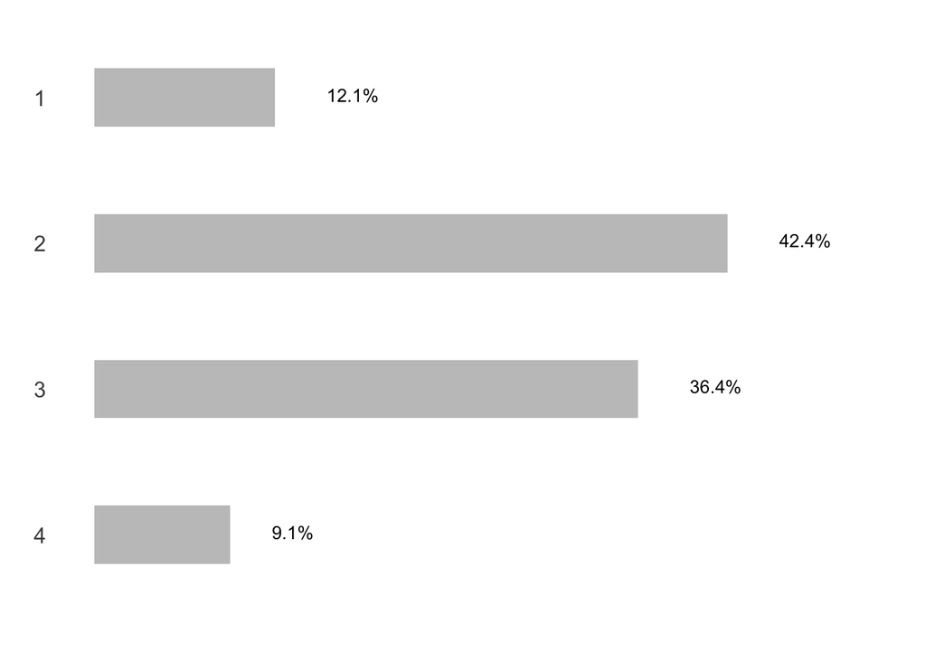

#### Scrum

##### Are you familiar with scrum?

- 1 - No, I do not know what scrum is
- 2 - I know a little bit about scrum
- 3 - Yes, I understand scrum theory but I do not have much experience
- 4 - Yes, I work on a scrum team and practice scrum everyday

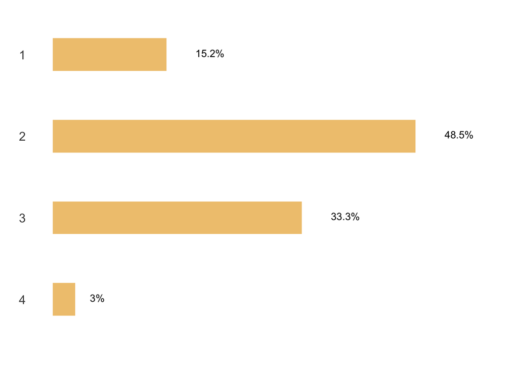

#### Programming

##### Do you have programming experience?

- 1 - No, I have never done programming
- 2 - I have a little bit of experience (scripts, sql, spreadsheets, etc.)
- 3 - I have some experience coding and creating software
- 4 - I have many years of experience working as a programmer

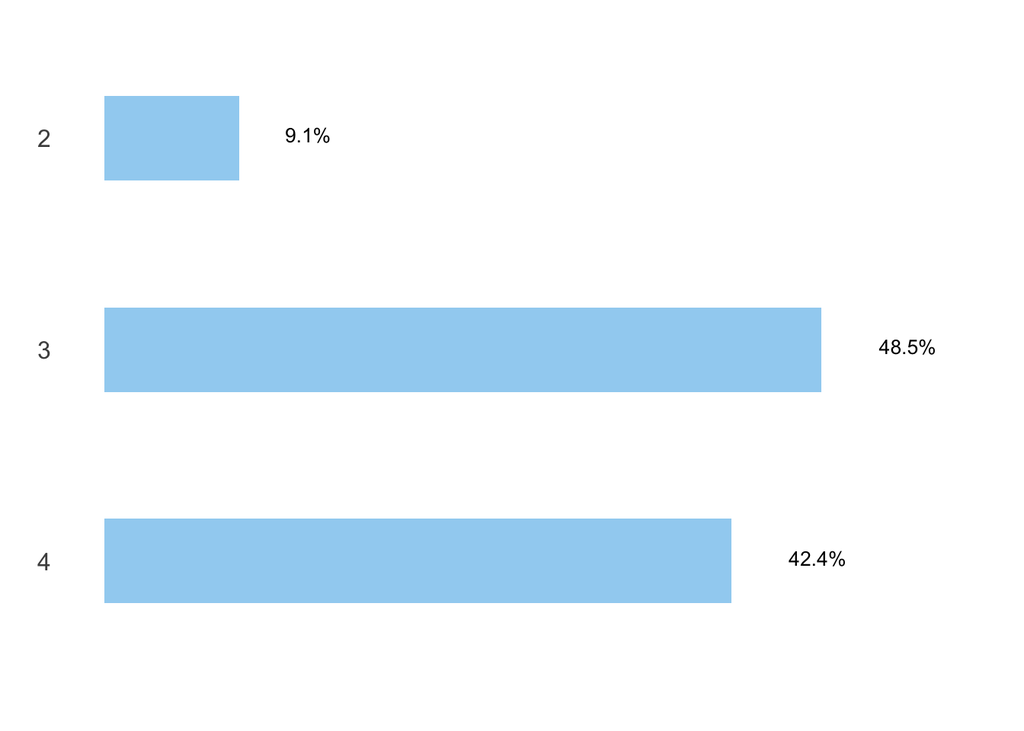

#### Amazon Web Services

##### What is your knowledge level of Amazon Web Services(AWS)

- 1 - I do not have experience using AWS
- 2 - I have a little bit of experience using a few specific AWS tools (EC2, S3, R53, etc.)
- 3 - I have moderate experience using a range of AWS tools
- 4 - I have several years of significant experience working with AWS

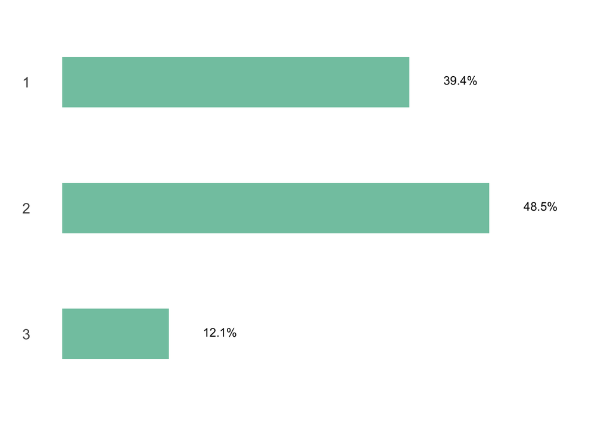

#### Hardware or Vehicle Engineering

##### What is your experience level with hardware or vehicle engineering?

- 1 - I have no experience
- 2 - I have a little bit of experience
- 3 - I have a moderate amount of experience
- 4 - I am very experienced
- 5 - I am an expert vehicle

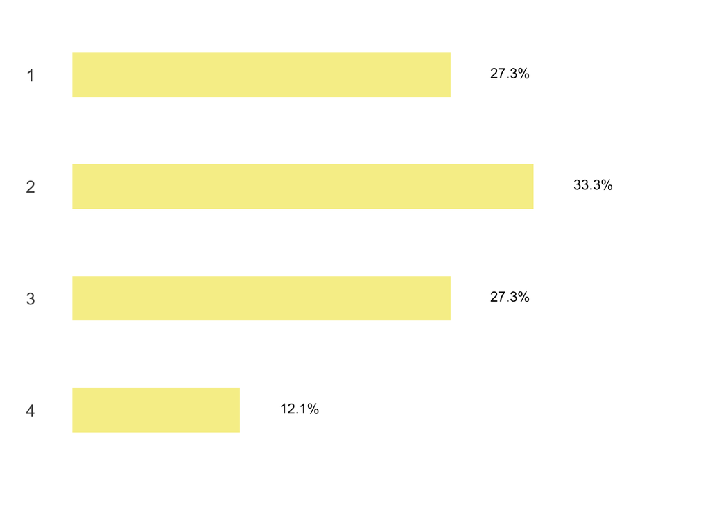

## Part 4: Skill Known vs. Skill Needed

#### Description:

##### This part provides insights on the different between skills used in respondents’ current job and the skills they think they know well

### Top 5 Current Job Skill/Know Well Skill

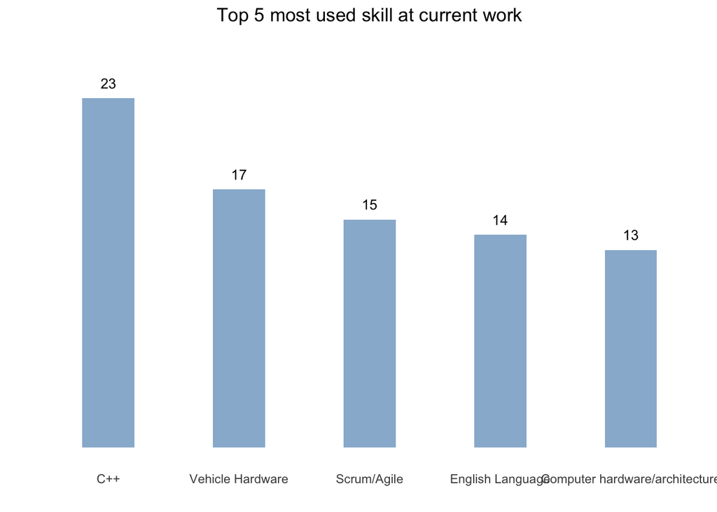

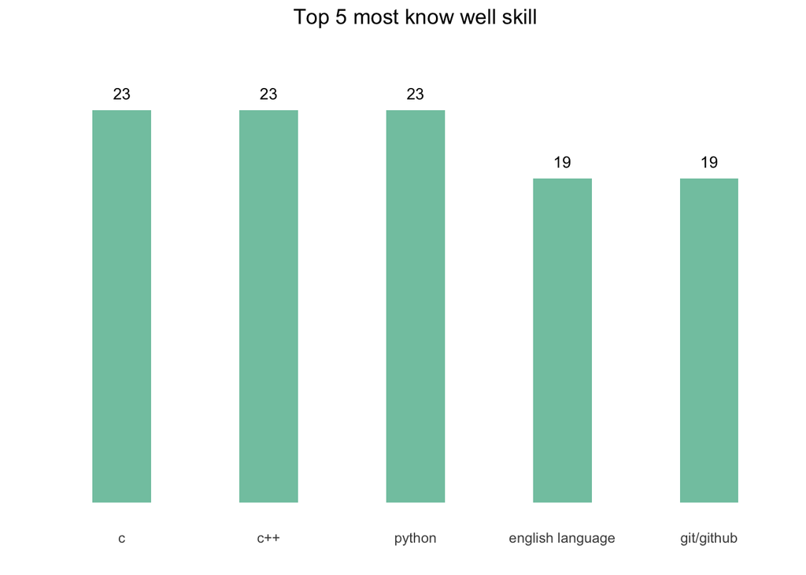

| rank | current_role_skill | vote | vote_pct |
| --- | --- | --- | --- |
| 1 | C++ | 23 | 69.7% |
| 2 | Vehicle Hardware | 17 | 51.52% |
| 3 | Scrum/Agile | 15 | 45.45% |
| 4 | English Language | 14 | 42.42% |
| 5 | Computer hardware/architecture | 13 | 39.39% |

| rank | know_well_skill | vote | vote_pct |
| --- | --- | --- | --- |
| 1 | c | 23 | 69.7% |
| 2 | c++ | 23 | 69.7% |
| 3 | python | 23 | 69.7% |
| 4 | english language | 19 | 57.58% |
| 5 | git/github | 19 | 57.58% |

### Current Role Skill VS Know Well Skill Vote Percentage Scatter Plot

##### Based on the plot, below are the skills voted for current job but only a few people vote they know it well

scrum/agile | vehicle hardware

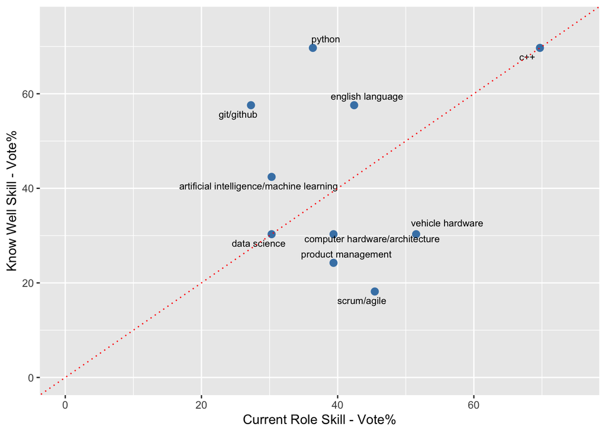

### Current Role Skill VS Know Well Skill Vote Percentage Delta table

| current_role_skill | pct_cur_role | pct_know_well | skill_pct_delta |
| --- | --- | --- | --- |
| c++ | 69.7% | 69.7% | 0% |
| vehicle hardware | 51.52% | 30.3% | 21.22% |
| scrum/agile | 45.45% | 18.18% | 27.27% |
| english language | 42.42% | 57.58% | -15.16% |
| computer hardware/architecture | 39.39% | 30.3% | 9.09% |
| product management | 39.39% | 24.24% | 15.15% |
| python | 36.36% | 69.7% | -33.34% |
| artificial intelligence/machine learning | 30.3% | 42.42% | -12.12% |
| data science | 30.3% | 30.3% | 0% |
| git/github | 27.27% | 57.58% | -30.31% |

## Part 5: Remote Work / WFH Situation

### Q: Under normal conditions (No coronovirus), How often would you like to work from home?

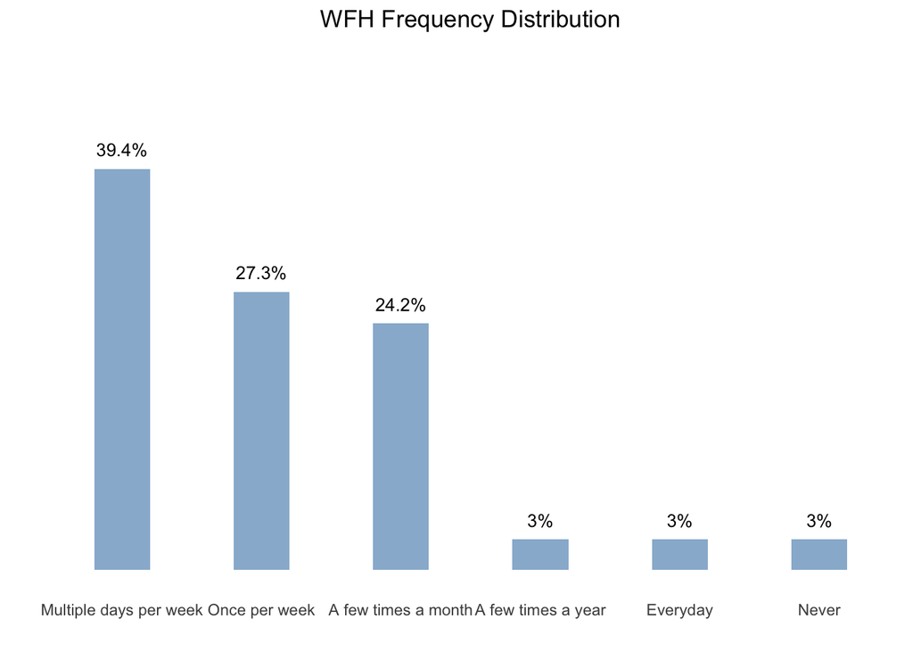

### Q: During our Coronavirus office restrictions, How difficult was each of the following?

* 1 - Not difficult  
* 2 - Slightly difficult  
* 3 - Moderately difficult  
* 4 - Very difficult  
* 5 - Nearly impossible/very severe

- Respondents generally have slight to moderate level of difficulty communicating with internal and external team members

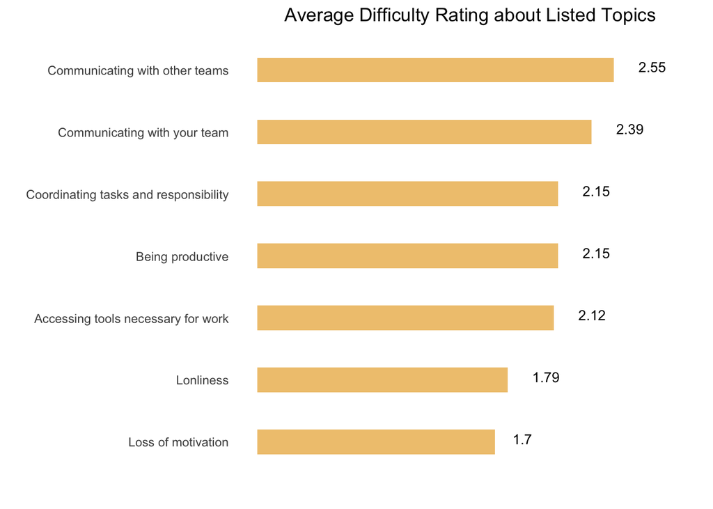